# Introduction to Logistic Regression, Species Distribution and Habitat Selection - Part 2

## Investigate Collinearity

Like any other analysis, we need to evaluate redundancy between our predictor variables to make sure they are sufficiently independent. Otherwise, we may obtain be unable to interpret our model. As Ramiro suggested, we will conduct a Variance Inflation Factor Analysis (VIF). Any variables with a VIF > 3 are potential cause for concern. Are any of the continuous variables included in our analysis highly collinear?

**Question:**

1. What do we do with categorical variables?

```r
# Assess the continuous variables we'll include in our analysis
vifstep(Occ[,22:26]) # Including scaled Human Presence, NDVI, roughness, and Dorcas/Addax
```

```
## No variable from the 5 input variables has collinearity problem.
##
## The linear correlation coefficients ranges between:
## min correlation ( sAddax ~ sDorcas ):  0.002850639
## max correlation ( srough ~ sndvi ):  -0.3029674
##
## ---------- VIFs of the remained variables --------
##   Variables      VIF
## 1    sHuman 1.056243
## 2     sndvi 1.126290
## 3    srough 1.173900
## 4   sDorcas 1.044492
## 5    sAddax 1.005890
```

```r
# You could also use the cor function to investigate correlation.
# What is a reasonable correlation threshold to use |0.65|??
#cor(Occ[,22:26])
```

## Generalized Linear Regression (GLM)

Model the occurrence of addax in a Generalized Linear Regression (GLM) framework. We expected non-linear relationships with surface roughness and ndvi, so are including these terms as quadratic effects in the model. Our goal *here* was not necessarily to create the very best model. Instead, we aimed to:

1. Identify the relationships between **all** reasonable predictor variables and addax occurrence
2. Evaluate a sub-model that contains only the remote sensing layers to make a prediction of habitat suitability that can be extrapolated across the landscape

**Question:**

1. Why is using a GLM advantageous given the data and objectives?

```r
# Create a full model with all the variables you think are important predictors of addax occurrence
glm.Addax <- glm(obsAddax ~ srough + I(srough^2) + sndvi + I(sndvi^2) + sHuman + sDorcas + Stipa1 + Stipa2 + Cornul + Season + Year,
                 data = Occ,
                 family = binomial(link="logit"))
# Summarize result
summary(glm.Addax)
```

```
##
## Call:
## glm(formula = obsAddax ~ srough + I(srough^2) + sndvi + I(sndvi^2) +
##     sHuman + sDorcas + Stipa1 + Stipa2 + Cornul + Season + Year,
##     family = binomial(link = "logit"), data = Occ)
##
## Deviance Residuals:
##     Min       1Q   Median       3Q      Max
## -1.5500  -0.5064  -0.3349  -0.1681   3.1546
##
## Coefficients:
##             Estimate Std. Error z value Pr(>|z|)
## (Intercept) -0.07121    0.43160  -0.165 0.868952
## srough       0.86802    0.18473   4.699 2.62e-06 ***
## I(srough^2) -0.63018    0.13657  -4.614 3.94e-06 ***
## sndvi       -0.02020    0.17877  -0.113 0.910034
## I(sndvi^2)  -0.27708    0.10595  -2.615 0.008919 **
## sHuman      -0.52754    0.20174  -2.615 0.008926 **
## sDorcas      0.13160    0.12617   1.043 0.296935
## Stipa11     -0.24188    0.25179  -0.961 0.336730
## Stipa21      1.12983    0.26516   4.261 2.04e-05 ***
## Cornul1      0.50166    0.27471   1.826 0.067832 .
## SeasonDry   -0.45680    0.36423  -1.254 0.209786
## SeasonWet   -0.45523    0.34035  -1.338 0.181051
## Year2009    -1.25168    0.49582  -2.524 0.011587 *
## Year2010    -1.85944    0.50081  -3.713 0.000205 ***
## Year2011    -1.78724    0.60077  -2.975 0.002931 **
## Year2012    -2.54471    0.62337  -4.082 4.46e-05 ***
## Year2013    -1.07119    0.47761  -2.243 0.024910 *
## Year2014    -3.61324    0.57505  -6.283 3.31e-10 ***
## ---
## Signif. codes:  0 '***' 0.001 '**' 0.01 '*' 0.05 '.' 0.1 ' ' 1
##
## (Dispersion parameter for binomial family taken to be 1)
##
##     Null deviance: 773.74  on 989  degrees of freedom
## Residual deviance: 616.17  on 972  degrees of freedom
## AIC: 652.17
##
## Number of Fisher Scoring iterations: 6
```

```r
# Nice summary table, including model estimates and odds ratios
tab_model(glm.Addax)
```

|  | obsAddax |  |  |
| --- | --- | --- | --- |
| Predictors | Odds Ratios | CI | p |
| (Intercept) | 0.93 | 0.40 – 2.17 | 0.869 |
| srough | 2.38 | 1.68 – 3.47 | **<0.001** |
| srough^2 | 0.53 | 0.40 – 0.68 | **<0.001** |
| sndvi | 0.98 | 0.69 – 1.39 | 0.910 |
| sndvi^2 | 0.76 | 0.60 – 0.92 | **0.009** |
| sHuman | 0.59 | 0.38 – 0.84 | **0.009** |
| sDorcas | 1.14 | 0.86 – 1.42 | 0.297 |
| Stipa1 [1] | 0.79 | 0.48 – 1.29 | 0.337 |
| Stipa2 [1] | 3.10 | 1.85 – 5.25 | **<0.001** |
| Cornul [1] | 1.65 | 0.97 – 2.86 | 0.068 |
| Season [Dry] | 0.63 | 0.31 – 1.30 | 0.210 |
| Season [Wet] | 0.63 | 0.32 – 1.23 | 0.181 |
| Year [2009] | 0.29 | 0.11 – 0.75 | **0.012** |
| Year [2010] | 0.16 | 0.06 – 0.41 | **<0.001** |
| Year [2011] | 0.17 | 0.05 – 0.53 | **0.003** |
| Year [2012] | 0.08 | 0.02 – 0.26 | **<0.001** |
| Year [2013] | 0.34 | 0.13 – 0.87 | **0.025** |
| Year [2014] | 0.03 | 0.01 – 0.08 | **<0.001** |
| Observations | 990 |  |  |
| R<sup>2</sup> Tjur | 0.186 |  |  |

```r
# Or print the confidence intervals
#confint(glm.Addax)
```

## Graph and Interpret

Use the `visreg` and `coefplot` functions to easily graph the results from a glm and evaluate the model output. Be careful, however, with how categorical variables are interpreted. `Visreg` does the hard parts of providing a predictive response while holding all other variables constant (similar to Ramiro’s example).

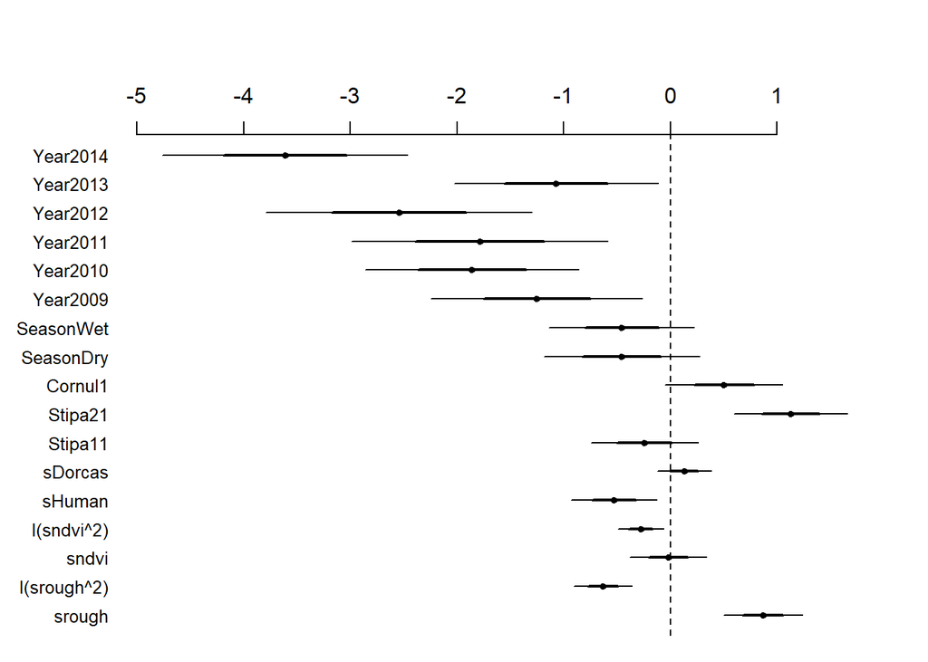

```r
# Plot the coefficients
coefplot(glm.Addax,
        plot=TRUE,
        mar=c(1,4,5.1,2),
        intercept=FALSE,
        vertical=TRUE,
        main="",
        var.las=1,
        frame.plot=FALSE)
```

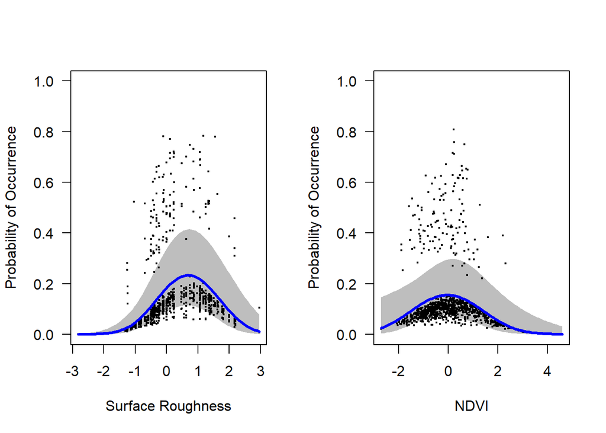

```r
# Reset plotting
par(mar=c(5,4,4,2)+0.1)

# Graph result for all variables
#visreg(glm.Addax, scale="response", ylab="Prob", partial=TRUE)

# Or just one variable at a time
par(mfrow=c(1,2))
visreg(glm.Addax,"srough",
       scale="response",
       ylab="Probability of Occurrence",
       xlab="Surface Roughness",
       partial=TRUE,
       line=list(col="blue"),
       fill=list(col="gray"),
       points=list(col="black",cex=0.25,pch=19),
       ylim=c(0,1))
visreg(glm.Addax,"sndvi",
       scale="response",
       ylab="Probability of Occurrence",
       xlab="NDVI",
       partial=TRUE,
       line=list(col="blue"),
       fill=list(col="gray"),
       points=list(col="black",cex=0.25,pch=19),
       ylim=c(0,1))
```

```r
par(mfrow=c(1,1))
```

## Model Validation

Binomial data can be notoriously difficult to validate, at least when compared to standard tools used for linear regression. Ramiro discussed a few techniques to assess model assumptions, including ways to assess a model’s predictive power. We will calculate the Area Under the Curve (AUC) to assess predictive power here. AUC compares the difference between the true positive classification rate and a false positive rate (i.e., Specificity vs Sensitivity). More details will be provided on AUC in the next few weeks of class. We will also use a cross-validation technique, dividing the input data into different “folds” and comparing the output predictions with these data subsets. Another (best) option is to incorporate an independent dataset for validation. Some guidelines for AUC:

- 0.9 - 1: Excellent (A)
- 0.8 - 0.9: Good (B)
- 0.7 - 0.8: Fair (C)
- 0.6 - 0.7: Poor (D)
- 0.5 - 0.6: Fail (F)

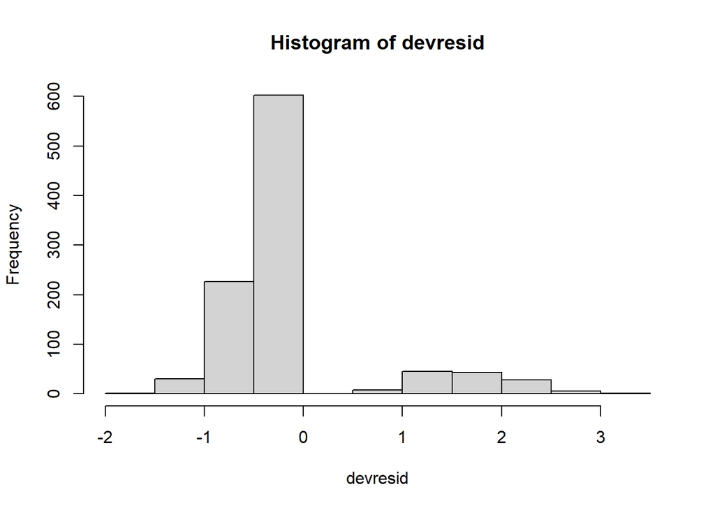

```r
# Evaluate deviance residuals
# No strong evidence of lack of fit.  Most residuals are around a value of 0.
devresid <- resid(glm.Addax, type = "deviance")
hist(devresid)
```

```r
# Calculate AUC
predpr <- predict(glm.Addax, type=c("response"))
(roccurve <- roc(Occ$obsAddax ~ predpr))
```

```
##
## Call:
## roc.formula(formula = Occ$obsAddax ~ predpr)
##
## Data: predpr in 859 controls (Occ$obsAddax 0) < 131 cases (Occ$obsAddax 1).
## Area under the curve: 0.8116
```

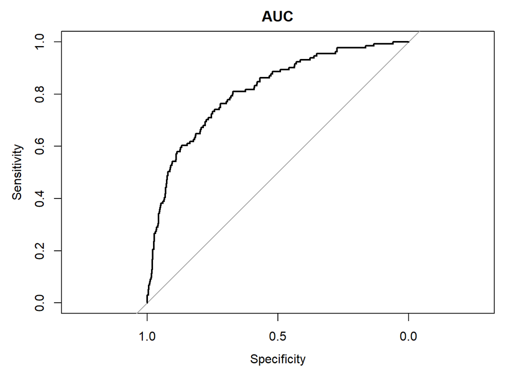

```r
plot(roccurve, main="AUC")
```

```r
# Calculate cross-validation statistic
cv.binary(glm.Addax)
```

```
##
## Fold:  5 8 1 2 7 3 9 10 4 6
## Internal estimate of accuracy = 0.872
## Cross-validation estimate of accuracy = 0.868
```

## Make a Predictive Surface

One of the most valuable parts of a species distribution model is predicting to locations where surveys were not performed. In order to make a prediction at these locations, we need predictor data that has wall-to-wall coverage. Unfortunately, only two of our layers incorporated in the full model have full coverage (*NDVI* and *Surface Roughness*).

Create a model with these two layers, assess how the model compares with the full model and predict across the entire study area. As you will see, model statistics indicate that this sub-model is not as good as the full model (compare the AIC, AUC).

The model, however, can still be useful, as long as we are clear about its shortcomings (e.g., we’d expect the predictive power to be decreased since we are not including the fine scale data collected at individual plot locations).

### Create Model Subset

```r
glm.Addax2 <- glm(obsAddax ~ srough + I(srough^2) + sndvi + I(sndvi^2),
                  data = Occ,
                  family = binomial(link="logit"))

# Summarize and print confidence intervals
summary(glm.Addax2)
```

```
##
## Call:
## glm(formula = obsAddax ~ srough + I(srough^2) + sndvi + I(sndvi^2),
##     family = binomial(link = "logit"), data = Occ)
##
## Deviance Residuals:
##     Min       1Q   Median       3Q      Max
## -0.7518  -0.6128  -0.4999  -0.3055   2.9167
##
## Coefficients:
##             Estimate Std. Error z value Pr(>|z|)
## (Intercept) -1.31025    0.13616  -9.623  < 2e-16 ***
## srough       0.63602    0.15559   4.088 4.35e-05 ***
## I(srough^2) -0.55024    0.12642  -4.352 1.35e-05 ***
## sndvi        0.08772    0.12001   0.731   0.4648
## I(sndvi^2)  -0.21425    0.08969  -2.389   0.0169 *
## ---
## Signif. codes:  0 '***' 0.001 '**' 0.01 '*' 0.05 '.' 0.1 ' ' 1
##
## (Dispersion parameter for binomial family taken to be 1)
##
##     Null deviance: 773.74  on 989  degrees of freedom
## Residual deviance: 734.51  on 985  degrees of freedom
## AIC: 744.51
##
## Number of Fisher Scoring iterations: 6
```

```r
# View model output with odds ratios
tab_model(glm.Addax2)
```

|  | obsAddax |  |  |
| --- | --- | --- | --- |
| Predictors | Odds Ratios | CI | p |
| (Intercept) | 0.27 | 0.21 – 0.35 | **<0.001** |
| srough | 1.89 | 1.41 – 2.59 | **<0.001** |
| srough^2 | 0.58 | 0.44 – 0.73 | **<0.001** |
| sndvi | 1.09 | 0.86 – 1.38 | 0.465 |
| sndvi^2 | 0.81 | 0.67 – 0.95 | **0.017** |
| Observations | 990 |  |  |
| R<sup>2</sup> Tjur | 0.034 |  |  |

```r
# Calculate AUC
predpr <- predict(glm.Addax2, type=c("response"))
(roccurve <- roc(Occ$obsAddax ~ predpr))
```

```
##
## Call:
## roc.formula(formula = Occ$obsAddax ~ predpr)
##
## Data: predpr in 859 controls (Occ$obsAddax 0) < 131 cases (Occ$obsAddax 1).
## Area under the curve: 0.6573
```

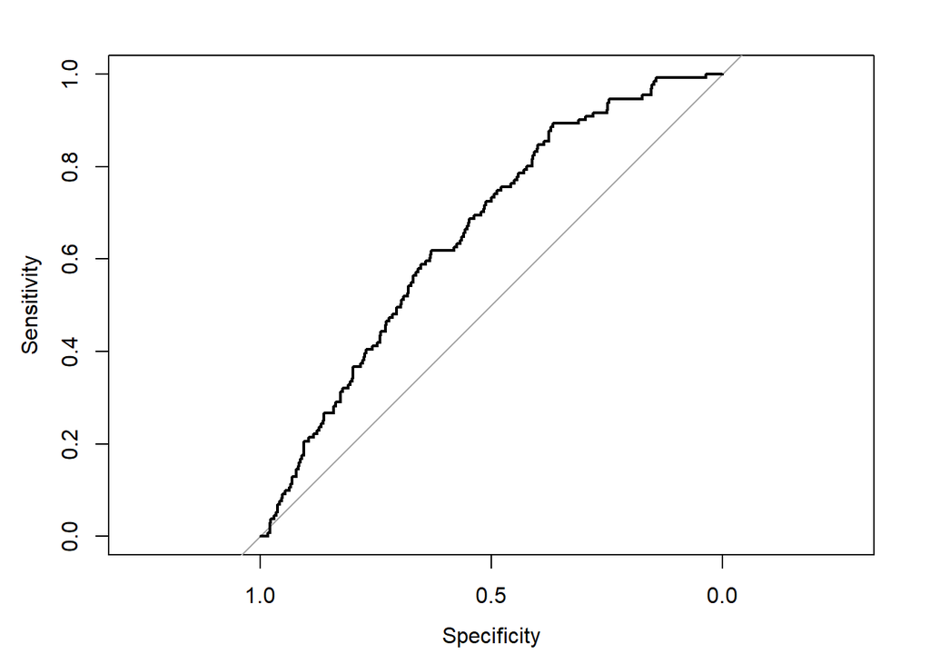

```r
plot(roccurve) # Not great
```

```r
# Calculate cross-validation statistic
cv.binary(glm.Addax2)
```

```
##
## Fold:  2 6 7 9 4 10 1 8 3 5
## Internal estimate of accuracy = 0.868
## Cross-validation estimate of accuracy = 0.868
```

**Question:**

1. Is our reduced model as good as our full model? How can you tell?

### Raster Prediction

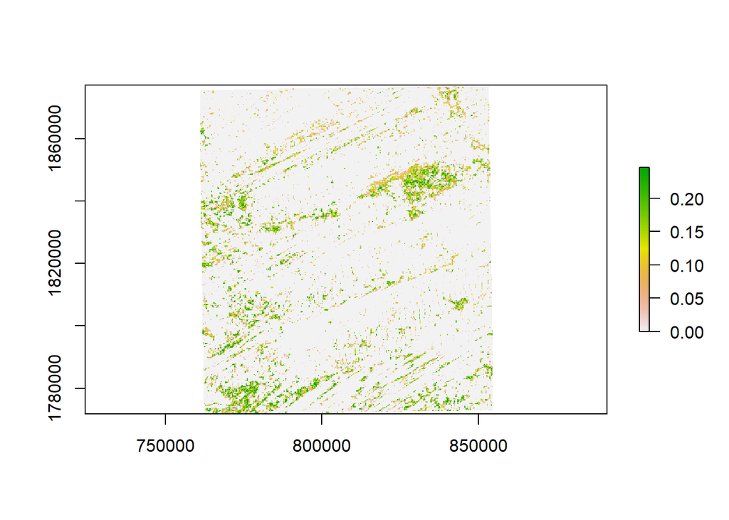

```r
# We could physically calculate the prediction from the model coefficients:
#coef <- summary(glm.Addax2)
#coef <- coef$coefficients
#coef

#Addax.predict <- (exp(coef[1] + s.rough*coef[2] + s.rough^2*coef[3] + s.ndvi*coef[4] + s.ndvi^2*coef[5])/(1 + exp(coef[1] + s.rough*coef[2] + s.rough^2*coef[3] + s.ndvi*coef[4] + s.ndvi^2*coef[5])))

# Add to brick and rename layer names
satImage <- brick(s.rough, s.ndvi) # Use brick here, rather than stack to create a single, multi-layer file
names(satImage) <- c("srough", "sndvi")

# Predict and export image to directory
Addax.predict <- predict(satImage, glm.Addax2, type="response", progress='text')
# Plot result
plot(Addax.predict) # Not a great prediction, with mostly low values, but it highlights some important aeras.
```

# Interactive Mapping

Lastly, we can take this one step further and plot our predicted surface on an interactive map, so that we have a better idea of its context in the real world and also provide a way to post our results on relevant social media.

```r
# Load ESRI imagery baselayer
tmap_mode("view")
tm_basemap("Esri.WorldImagery") +
  tm_shape(Addax.predict, name = "Addax prediction") +
  tm_raster(palette="-inferno", n=8, alpha=0.6,
            title = "Predicted Addax Occurrence")
```

[interactive chart not shown]